```python
#Importing the packages
import numpy as np
import pandas as pd
import scipy.stats as stats
import matplotlib.pyplot as plt
import seaborn as sns
```

# PART 1

# Question 1

```python
# 1. Refer to the above table and find the joint probability of the people who planned to purchase and actually
# placed an order.
print('the joint probability of the people who planned to purchase and actually placed an order is 400/500 i.e 0.8.')
# 2. Refer to the above table and find the joint probability of the people who planned to purchase and actually
# placed an order, given that people planned to purchase.
print('the joint probability of the people who planned to purchase and actually placed an order, given that people planned to purchase. 400/200 i.e 2.')
```

[output not shown]

# Question 2

```python
#Soultion 1
p = 0.05
n=10
k=np.arange(0,11)
binomial = stats.binom.pmf(k,n,p)
print(binomial)

cumbinomial = stats.binom.cdf(k,n,p)
print(cumbinomial)
```

```
[5.98736939e-01 3.15124705e-01 7.46347985e-02 1.04750594e-02
 9.64808106e-04 6.09352488e-05 2.67259863e-06 8.03789063e-08
 1.58642578e-09 1.85546875e-11 9.76562500e-14]
[0.59873694 0.91386164 0.98849644 0.9989715  0.99993631 0.99999725
 0.99999992 1.         1.         1.         1.        ]
```

```python
# A. Probability that none of the items are defective?
print('a) none of the items are defective is %1.4f' %binomial[0])

# B. Probability that exactly one of the items is defective?
print('b) exactly one of the items is defective is %1.4f' %binomial[1])

# C. Probability that two or fewer of the items are defective?
print('c)two or fewer of the items are defective is %1.4f' %cumbinomial[2])

# D. Probability that three or more of the items are defective?
P = 1- cumbinomial[2]
print('d) three or more of the items are defective is %1.4f' %P)
```

[output not shown]

# Question 3

```python
rate = 3
n=np.arange(0,20)
poisson = stats.poisson.pmf(n,rate)
print(poisson)
```

```
[4.97870684e-02 1.49361205e-01 2.24041808e-01 2.24041808e-01
 1.68031356e-01 1.00818813e-01 5.04094067e-02 2.16040315e-02
 8.10151179e-03 2.70050393e-03 8.10151179e-04 2.20950322e-04
 5.52375804e-05 1.27471339e-05 2.73152870e-06 5.46305740e-07
 1.02432326e-07 1.80762929e-08 3.01271548e-09 4.75691918e-10]
```

```
a)Probability that in a given week he will sell some cars. 0.9502
b)Probability that in a given week he will sell 2 or more but less than 5 cars. 0.6161
```

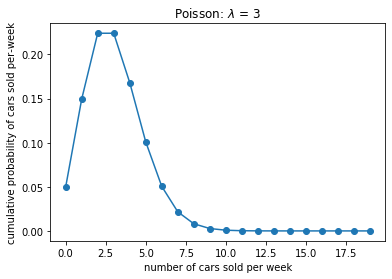

```python
# A. Probability that in a given week he will sell some cars.
a = 1-poisson[0]
print('a)Probability that in a given week he will sell some cars. %1.4f' %a)

# B. Probability that in a given week he will sell 2 or more but less than 5 cars.
b= poisson[2]+poisson[3]+poisson[4]
print('b)Probability that in a given week he will sell 2 or more but less than 5 cars. %1.4f' %b)

# C. Plot the poisson distribution function for cumulative probability of cars sold per-week vs number of cars sold per-week.
plt.plot(n,poisson,'o-')
plt.title('Poisson: $\lambda$ = %i ' % rate)
plt.xlabel('number of cars sold per week')
plt.ylabel('cumulative probability of cars sold per-week')
plt.show()
```

# Question 4

```python
p=0.868
q=1-p
n=3
k=np.arange(0,11)
binomial = stats.binom.pmf(k,n,q)
print(binomial)

cumbinomial = stats.binom.cdf(k,n,p)
print(cumbinomial)
```

```
[0.65397203 0.2983559  0.0453721  0.00229997 0.         0.
 0.         0.         0.         0.         0.        ]
[0.00229997 0.04767206 0.34602797 1.         1.         1.
 1.         1.         1.         1.         1.        ]
```

```python
# A. What is the probability that all three orders will be recognised correctly?
print('a)probability that all three orders will be recognised correctly. %1.4f' %binomial[2])

# B. What is the probability that none of the three orders will be recognised correctly?
print('b)Probability that none of the three orders will be recognised correctly. %1.4f' %binomial[0])

# C. What is the probability that at least two of the three orders will be recognised correctly?
P = 1 - cumbinomial[1]
print('c)probability that at least two of the three orders will be recognised correctly. %1.4f' %P)
```

[output not shown]

# Question 5

```python
# mean = 60
std = 12
n=300
# A. What is the percentage of students who score more than 80.
a = 1-stats.norm.cdf(80,mean,std)
percentage_80 = (a*100)/n
print('a)percentage of students who score more than 80:',percentage_80)

# B. What is the percentage of students who score less than 50.
b= stats.norm.cdf(50,mean,std)
percentage_50 = (b*100)/n
print('b)percentage of students who score less than 50.: %1.4f' %percentage_50)
```

[output not shown]

# Question 6

# Statistics are used in the field of medicine. # They can be used to calculate the probability of average consultations a doctor attends, the number of births and deaths. # Especially during this pandemic scenario, statistics help in identifying the number of people tested positive, # discharged patients and future predictions like the percentage of increase in cases, the number of oxygen cylinders needed and # the number of beds available, the number of beds needed more., the effectiveness of vaccination and medicines provided .etc.

# PART 2

```python
#Read the csv file.
basketball = pd.read_csv('DS - Part2 - Basketball.csv')
basketball.head()
```

|  | Team | Tournament | Score | PlayedGames | WonGames | DrawnGames | LostGames | BasketScored | BasketGiven | TournamentChampion | Runner-up | TeamLaunch | HighestPositionHeld |
| --- | --- | --- | --- | --- | --- | --- | --- | --- | --- | --- | --- | --- | --- |
| 0 | Team 1 | 86 | 4385 | 2762 | 1647 | 552 | 563 | 5947 | 3140 | 33 | 23 | 1929 | 1 |
| 1 | Team 2 | 86 | 4262 | 2762 | 1581 | 573 | 608 | 5900 | 3114 | 25 | 25 | 1929 | 1 |
| 2 | Team 3 | 80 | 3442 | 2614 | 1241 | 598 | 775 | 4534 | 3309 | 10 | 8 | 1929 | 1 |
| 3 | Team 4 | 82 | 3386 | 2664 | 1187 | 616 | 861 | 4398 | 3469 | 6 | 6 | 1931to32 | 1 |
| 4 | Team 5 | 86 | 3368 | 2762 | 1209 | 633 | 920 | 4631 | 3700 | 8 | 7 | 1929 | 1 |

```python
#Print the last 5 rows of the dataset.
basketball.tail()
```

|  | Team | Tournament | Score | PlayedGames | WonGames | DrawnGames | LostGames | BasketScored | BasketGiven | TournamentChampion | Runner-up | TeamLaunch | HighestPositionHeld |
| --- | --- | --- | --- | --- | --- | --- | --- | --- | --- | --- | --- | --- | --- |
| 56 | Team 57 | 1 | 34 | 38 | 8 | 10 | 20 | 38 | 66 | - | - | 2009-10 | 20 |
| 57 | Team 58 | 1 | 22 | 30 | 7 | 8 | 15 | 37 | 57 | - | - | 1956-57 | 16 |
| 58 | Team 59 | 1 | 19 | 30 | 7 | 5 | 18 | 51 | 85 | - | - | 1951~52 | 16 |
| 59 | Team 60 | 1 | 14 | 30 | 5 | 4 | 21 | 34 | 65 | - | - | 1955-56 | 15 |
| 60 | Team 61 | 1 | - | - | - | - | - | - | - | - | - | 2017~18 | 9 |

# We could find there are blanks or '-' in the dataset.

```python
#Printing the row and column of the dataset.
basketball.shape
```

```
(61, 13)
```

```python
basketball.info()
```

```
<class 'pandas.core.frame.DataFrame'>
RangeIndex: 61 entries, 0 to 60
Data columns (total 13 columns):
Team                   61 non-null object
Tournament             61 non-null int64
Score                  61 non-null object
PlayedGames            61 non-null object
WonGames               61 non-null object
DrawnGames             61 non-null object
LostGames              61 non-null object
BasketScored           61 non-null object
BasketGiven            61 non-null object
TournamentChampion     61 non-null object
Runner-up              61 non-null object
TeamLaunch             61 non-null object
HighestPositionHeld    61 non-null int64
dtypes: int64(2), object(11)
memory usage: 6.3+ KB
```

```python
basketball.describe()
```

|  | Tournament | HighestPositionHeld |
| --- | --- | --- |
| count | 61.000000 | 61.000000 |
| mean | 24.000000 | 7.081967 |
| std | 26.827225 | 5.276663 |
| min | 1.000000 | 1.000000 |
| 25% | 4.000000 | 3.000000 |
| 50% | 12.000000 | 6.000000 |
| 75% | 38.000000 | 10.000000 |
| max | 86.000000 | 20.000000 |

# We can infer that : The maximum tournament held is 86 and minimum number of tournament held is 1. The maximum position held is 20 (which is the lowest position ranging from 0-20) while the minimum position is 1.

```python
# Summarize null values(missing values) in dataset
basketball.isna().sum()
```

```
Team                   0
Tournament             0
Score                  0
PlayedGames            0
WonGames               0
DrawnGames             0
LostGames              0
BasketScored           0
BasketGiven            0
TournamentChampion     0
Runner-up              0
TeamLaunch             0
HighestPositionHeld    0
dtype: int64
```

```python
#Though there are no null values present there were '-' present in the dataset. Let us replace them with '0' first.
basketball.replace(to_replace= '-', value= 0, inplace=True)
basketball.tail()
```

|  | Team | Tournament | Score | PlayedGames | WonGames | DrawnGames | LostGames | BasketScored | BasketGiven | TournamentChampion | Runner-up | TeamLaunch | HighestPositionHeld |
| --- | --- | --- | --- | --- | --- | --- | --- | --- | --- | --- | --- | --- | --- |
| 56 | Team 57 | 1 | 34 | 38 | 8 | 10 | 20 | 38 | 66 | 0 | 0 | 2009-10 | 20 |
| 57 | Team 58 | 1 | 22 | 30 | 7 | 8 | 15 | 37 | 57 | 0 | 0 | 1956-57 | 16 |
| 58 | Team 59 | 1 | 19 | 30 | 7 | 5 | 18 | 51 | 85 | 0 | 0 | 1951~52 | 16 |
| 59 | Team 60 | 1 | 14 | 30 | 5 | 4 | 21 | 34 | 65 | 0 | 0 | 1955-56 | 15 |
| 60 | Team 61 | 1 | 0 | 0 | 0 | 0 | 0 | 0 | 0 | 0 | 0 | 2017~18 | 9 |

```python
# Removing '_','-','to','~' from the years in Team Launch.
basketball['TeamLaunch'] = basketball['TeamLaunch'].apply(lambda x: x.split('-')[0])
basketball['TeamLaunch'] = basketball['TeamLaunch'].apply(lambda x: x.split('to')[0])
basketball['TeamLaunch'] = basketball['TeamLaunch'].apply(lambda x: x.split('~')[0])
basketball['TeamLaunch'] = basketball['TeamLaunch'].apply(lambda x: x.split('_')[0])
basketball.head(5)
```

|  | Team | Tournament | Score | PlayedGames | WonGames | DrawnGames | LostGames | BasketScored | BasketGiven | TournamentChampion | Runner-up | TeamLaunch | HighestPositionHeld |
| --- | --- | --- | --- | --- | --- | --- | --- | --- | --- | --- | --- | --- | --- |
| 0 | Team 1 | 86 | 4385 | 2762 | 1647 | 552 | 563 | 5947 | 3140 | 33 | 23 | 1929 | 1 |
| 1 | Team 2 | 86 | 4262 | 2762 | 1581 | 573 | 608 | 5900 | 3114 | 25 | 25 | 1929 | 1 |
| 2 | Team 3 | 80 | 3442 | 2614 | 1241 | 598 | 775 | 4534 | 3309 | 10 | 8 | 1929 | 1 |
| 3 | Team 4 | 82 | 3386 | 2664 | 1187 | 616 | 861 | 4398 | 3469 | 6 | 6 | 1931 | 1 |
| 4 | Team 5 | 86 | 3368 | 2762 | 1209 | 633 | 920 | 4631 | 3700 | 8 | 7 | 1929 | 1 |

```python
#We will now convert the data type of the columns having numerical values to integer in order to perform operations.
#We can now convert the object except the column Team to integer to perform calculations
basketball['Score']=basketball['Score'].astype('int64')
basketball['PlayedGames']=basketball['PlayedGames'].astype('int64')
basketball['WonGames']=basketball['WonGames'].astype('int64')
basketball['DrawnGames']=basketball['DrawnGames'].astype('int64')
basketball['LostGames']=basketball['LostGames'].astype('int64')
basketball['BasketScored']=basketball['BasketScored'].astype('int64')
basketball['BasketGiven']=basketball['BasketGiven'].astype('int64')
basketball['TournamentChampion']=basketball['TournamentChampion'].astype('int64')
basketball['Runner-up']=basketball['Runner-up'].astype('int64')
basketball['TeamLaunch']=basketball['TeamLaunch'].astype('int64')
```

```python
#Checking the data type of the converted columns
basketball.dtypes
```

```
Team                   object
Tournament              int64
Score                   int64
PlayedGames             int64
WonGames                int64
DrawnGames              int64
LostGames               int64
BasketScored            int64
BasketGiven             int64
TournamentChampion      int64
Runner-up               int64
TeamLaunch              int64
HighestPositionHeld     int64
dtype: object
```

```python
#Lets consider data to be the final cleaned dataset.
data=basketball
data.head(3)
```

|  | Team | Tournament | Score | PlayedGames | WonGames | DrawnGames | LostGames | BasketScored | BasketGiven | TournamentChampion | Runner-up | TeamLaunch | HighestPositionHeld |
| --- | --- | --- | --- | --- | --- | --- | --- | --- | --- | --- | --- | --- | --- |
| 0 | Team 1 | 86 | 4385 | 2762 | 1647 | 552 | 563 | 5947 | 3140 | 33 | 23 | 1929 | 1 |
| 1 | Team 2 | 86 | 4262 | 2762 | 1581 | 573 | 608 | 5900 | 3114 | 25 | 25 | 1929 | 1 |
| 2 | Team 3 | 80 | 3442 | 2614 | 1241 | 598 | 775 | 4534 | 3309 | 10 | 8 | 1929 | 1 |

```python
# Five point summary of all continuous(numerical) variables
data.describe()
```

|  | Tournament | Score | PlayedGames | WonGames | DrawnGames | LostGames | BasketScored | BasketGiven | TournamentChampion | Runner-up | TeamLaunch | HighestPositionHeld |
| --- | --- | --- | --- | --- | --- | --- | --- | --- | --- | --- | --- | --- |
| count | 61.000000 | 61.000000 | 61.000000 | 61.000000 | 61.000000 | 61.000000 | 61.000000 | 61.000000 | 61.000000 | 61.000000 | 61.000000 | 61.000000 |
| mean | 24.000000 | 901.426230 | 796.819672 | 303.967213 | 188.934426 | 303.754098 | 1140.344262 | 1140.229508 | 1.426230 | 1.409836 | 1958.918033 | 7.081967 |
| std | 26.827225 | 1134.899121 | 876.282765 | 406.991030 | 201.799477 | 294.708594 | 1506.740211 | 1163.710766 | 5.472535 | 4.540107 | 27.484114 | 5.276663 |
| min | 1.000000 | 0.000000 | 0.000000 | 0.000000 | 0.000000 | 0.000000 | 0.000000 | 0.000000 | 0.000000 | 0.000000 | 1929.000000 | 1.000000 |
| 25% | 4.000000 | 96.000000 | 114.000000 | 34.000000 | 24.000000 | 62.000000 | 153.000000 | 221.000000 | 0.000000 | 0.000000 | 1935.000000 | 3.000000 |
| 50% | 12.000000 | 375.000000 | 423.000000 | 123.000000 | 95.000000 | 197.000000 | 430.000000 | 632.000000 | 0.000000 | 0.000000 | 1951.000000 | 6.000000 |
| 75% | 38.000000 | 1351.000000 | 1318.000000 | 426.000000 | 330.000000 | 563.000000 | 1642.000000 | 1951.000000 | 0.000000 | 0.000000 | 1978.000000 | 10.000000 |
| max | 86.000000 | 4385.000000 | 2762.000000 | 1647.000000 | 633.000000 | 1070.000000 | 5947.000000 | 3889.000000 | 33.000000 | 25.000000 | 2017.000000 | 20.000000 |

# Univariate Analysis For Continuous Variables

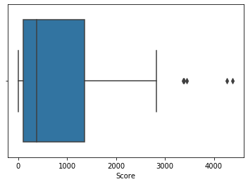

```python
sns.boxplot(x="Score",data=data)
```

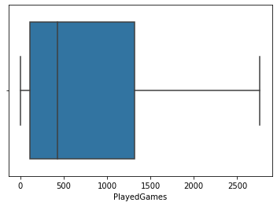

```python
sns.boxplot(x="PlayedGames",data=data)
```

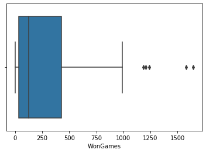

```python
sns.boxplot(x="WonGames",data=data)
```

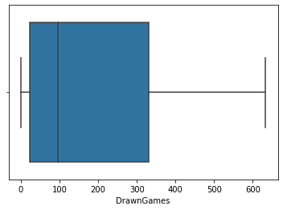

```python
sns.boxplot(x="DrawnGames",data=data)
```

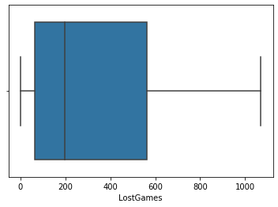

```python
sns.boxplot(x="LostGames",data=data)
```

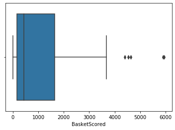

```python
sns.boxplot(x="BasketScored",data=data)
```

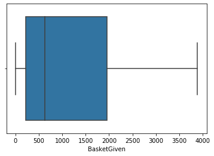

```python
sns.boxplot(x="BasketGiven",data=data)
```

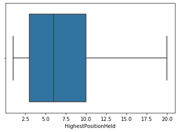

```python
sns.boxplot(x="HighestPositionHeld",data=data)
```

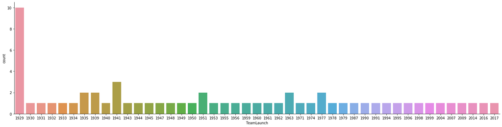

```python
#Lets find out the oldest team using the column Year.
sns.catplot(x="TeamLaunch",
                data=data, kind="count",
                 aspect=4);
```